# Tutorial 2: Building Toy Worlds

What a simulation is, and why scientists trust dice

**NoteWord list（単語リスト）**

| English | 日本語 | Meaning |
| --- | --- | --- |
| simulation | シミュレーション | letting a model “run” inside a computer |
| model | モデル | a simplified copy of something real |
| probability | 確率 | how likely something is (0 = never, 1 = always) |
| loop | ループ・繰り返し | telling R to repeat something many times |
| random walk | ランダムウォーク | a path built from random steps |

## What is a model?

A map of Tokyo is not Tokyo. It leaves out almost everything — and that’s exactly why it is useful.

A **model** is the same idea in science: a simplified copy of the real world that keeps only the parts we care about. A **simulation** is what happens when we let a model run inside a computer, like pressing “play”.

This week our models will be about **people (and animals) learning and copying each other**. But first, let’s build the simplest possible toy world.

## Experiment 1: How fair is a coin?

If you flip a fair coin 10 times, do you get exactly 5 heads?

```r
flips <- sample(c(1, 0), size = 10, replace = TRUE)  # 1 = heads, 0 = tails
flips
```

```
 [1] 0 1 0 1 1 1 1 1 1 0
```

```r
sum(flips)   # how many heads?
```

```
[1] 7
```

Run this a few times. Sometimes 3 heads, sometimes 7… Now the magic of simulation: **we don’t have to flip by hand.**

```r
n_heads <- replicate(10000, sum(sample(c(1, 0), size = 10, replace = TRUE)))
```

`replicate(10000, ...)` repeats our little experiment **ten thousand times** and collects the results. Let’s see them all:

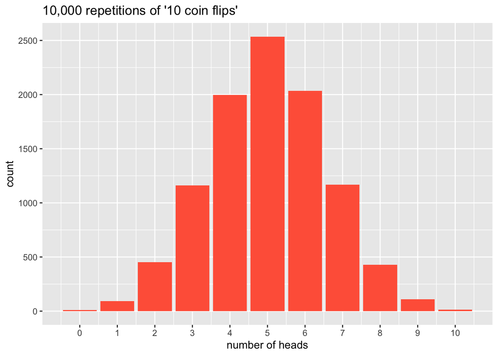

```r
library(ggplot2)
ggplot(data.frame(n_heads), aes(x = n_heads)) +
  geom_bar(fill = "tomato") +
  scale_x_continuous(breaks = 0:10) +
  labs(title = "10,000 repetitions of '10 coin flips'",
       x = "number of heads", y = "count")
```

**TipTry it! — how surprising is 9 heads?**

Using the vector `n_heads`:

```r
mean(n_heads >= 9)
```

This computes the fraction of experiments with 9 or 10 heads. If a friend flips 10 coins and gets 9 heads, should you suspect a trick coin? Write down your guess before you run the code.

*(This — estimating a probability by simulating many times — is called the **Monte Carlo method**. Real researchers use it constantly.)*

## Experiment 2: More flips, more truth

`set.seed(1)` makes the random numbers repeat exactly. This means your table will look like ours when you run the code.

```r
set.seed(1)
flip_average <- function(n_flips) {
  mean(sample(c(1, 0), size = n_flips, replace = TRUE))
}

results <- data.frame(
  n = c(10, 100, 1000, 10000),
  proportion_heads = c(flip_average(10), flip_average(100),
                       flip_average(1000), flip_average(10000))
)
results
```

```
      n proportion_heads
1    10            0.600
2   100            0.490
3  1000            0.496
4 10000            0.501
```

Small samples are wild; big samples settle near 0.5. This is the **law of large numbers** — and it is one reason why *averaging many opinions* can be powerful. Remember this for Day 3: it is the secret behind the “wisdom of crowds”.

## Writing our own function

We just did something important: we wrote our **own function**, `flip_average()`. A function is a recipe:

```r
name <- function(ingredients) {
  ... what to do ...
}
```

From now on we will build all our models as functions.

## Experiment 3: Can we predict a cockroach’s path?

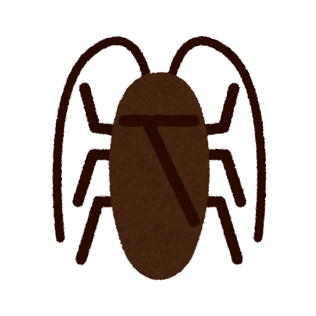

Imagine a pet cockroach in a long, narrow corridor. Where will it go? Our toy model gives it two possible moves at each time step:

- one step right (+1), with probability 0.5
- one step left (−1), with probability 0.5

Where might the cockroach be after 100 steps?

**NoteA toy cockroach, not a real one**

Real cockroaches do not choose steps by flipping coins. They use their antennae. They respond to walls, light, food, and other signals. Our model leaves all of this out on purpose. It asks a smaller question: **what kind of path can randomness alone create?**

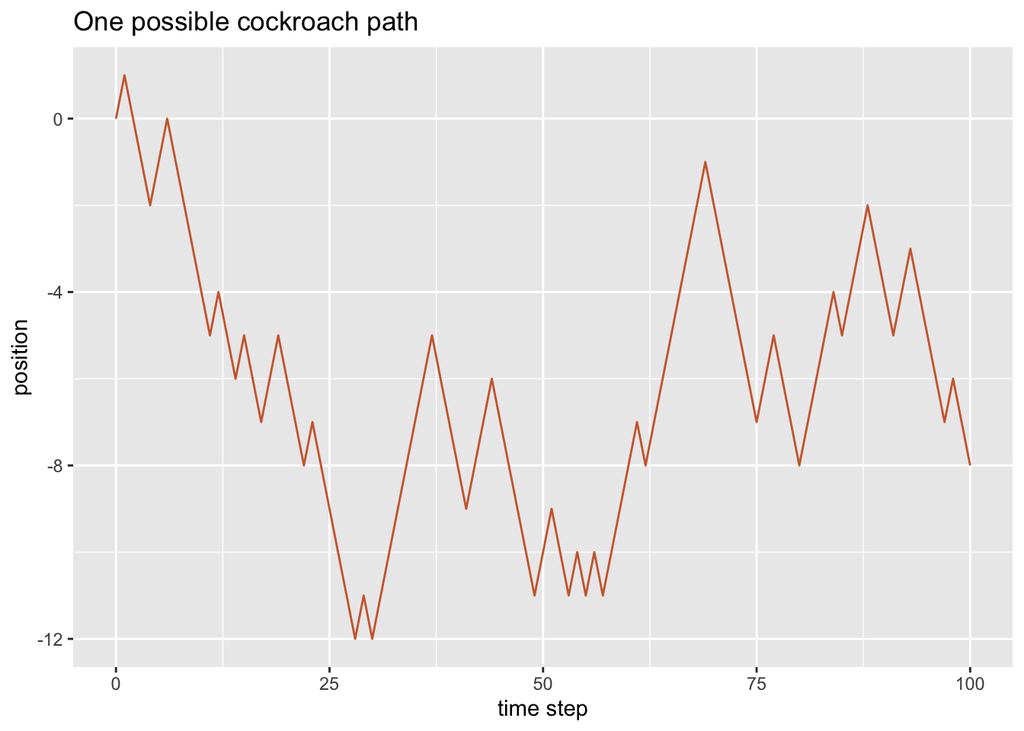

```r
steps <- sample(c(1, -1), size = 100, replace = TRUE)
position <- c(0, cumsum(steps))   # start at 0, then add each step
ggplot(data.frame(time = 0:100, position), aes(time, position)) +
  geom_line(color = "sienna3") +
  labs(title = "One possible cockroach path",
       x = "time step", y = "position")
```

Run it again. You will see a different possible path each time! To make many paths, we need a **for loop**（ループ・繰り返し）. A for loop repeats the code inside `{ }`. The value of `i` changes each time.

```r
for (i in 1:5) {
  print(i)
}
```

```
[1] 1
[1] 2
[1] 3
[1] 4
[1] 5
```

First, give our random-walk recipe a name:

```r
random_walk <- function(n_steps = 100) {
  c(0, cumsum(sample(c(1, -1), size = n_steps, replace = TRUE)))
}

random_walk(10)
```

```
 [1]  0 -1  0  1  2  1  2  1  0 -1 -2
```

Now let’s simulate **2,000 possible cockroach paths**. We will draw 40 paths on the left, so that we can still see each line. We will use all 2,000 final positions on the right.

```r
set.seed(2)
n_paths <- 2000
walks <- data.frame()
endpoints <- numeric(n_paths)
for (i in 1:n_paths) {
  one_path <- random_walk(100)
  endpoints[i] <- one_path[101]
  if (i <= 40) {
    walks <- rbind(walks, data.frame(time = 0:100,
                                     position = one_path, path = i))
  }
}
mean(endpoints)
```

```
[1] -0.052
```

The **mean（平均）** is the average final position. Right and left are equally likely, so the theoretical **expected mean（期待値）** is 0.

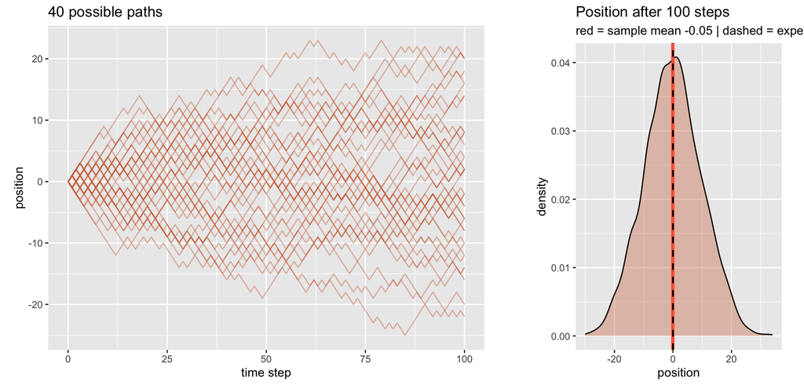

```r
p_paths <- ggplot(walks, aes(time, position, group = path)) +
  geom_line(alpha = 0.4, color = "sienna3") +
  labs(title = "40 possible paths",
       x = "time step", y = "position")

p_density <- ggplot(data.frame(position = endpoints), aes(position)) +
  geom_density(fill = "sienna3", alpha = 0.35) +
  geom_vline(xintercept = mean(endpoints), color = "tomato", linewidth = 1.4) +
  geom_vline(xintercept = 0, linetype = "dashed", linewidth = 0.7) +
  labs(title = "Position after 100 steps",
       subtitle = paste("red = sample mean", round(mean(endpoints), 2),
                        "| dashed = expected mean 0"))

grid::grid.newpage()
print(p_paths, vp = grid::viewport(x = 0.31, width = 0.60))
print(p_density, vp = grid::viewport(x = 0.82, width = 0.32))
```

We cannot predict one exact path. But the distribution（分布）on the right is stable. The red sample mean is almost on top of the dashed expected mean, 0. With many paths, positive and negative errors cancel each other.

**NoteWhat becomes stable?**

We fixed the time at 100 steps. More simulated paths give us a more stable estimate of the distribution **at that time**. If we let each cockroach walk for longer, the distribution will become wider.

**ImportantThe big idea**

**Individual outcomes can be unpredictable, while their average is predictable.** This is the law of large numbers again. When errors point in different directions, averaging can make them cancel. This is one reason why a crowd can sometimes be wise.

**TipTry it! — fewer paths and a biased cockroach**

1. Which sample mean will be more stable: 20 paths or 2,000 paths? Write down your prediction.
2. Change `n_paths` to `20`. Run both code blocks again. How did the red line and density change?
3. Restore `n_paths <- 2000`. Then give `+1` probability 0.6 and `-1` probability 0.4. Hint: add `prob = c(0.6, 0.4)` inside `sample()`. Predict where the red mean will move before you run the code.
4. What information would make this a better model of a real cockroach? Think about walls, light, food, or its previous step.

## What you learned

- A **model** is a deliberately simplified toy world; a **simulation** runs it
- `replicate()` and functions let us repeat experiments thousands of times
- Small samples lie; large samples tell the truth (law of large numbers)
- Simple random rules can create clear collective patterns

Next tutorial: our toy world gets its first **inhabitant** — an agent that can *learn*.